# oscillator

```python
%matplotlib notebook
import matplotlib.pyplot as plt
import numpy as np
import pandas as pd
```

Here, I aim to introduce some brief information about an important object from calculus and its applications -- the harmonic oscillator. This idea can be related to a basic problem involving a mass on a string. We say that the differential equation

$$ m \frac{d^2 x}{dy^2} + kx = 0$$

represents a basic harmonic oscillator.

To begin, please address the following questions:

1. Can you show that $\sin(x)$ is a solution to this differential equation?
2. Can you show that $\cos(x)$ is a solution?
3. Show that any combination of $\sin(x)$ and $\cos(x)$ are solutions to the equation?

### Qualitative Description

Despite the potentially obvious solutions from above in terms of trigonometric functions, we want to examine a qualitative solution to the problem. Just as in class, we can use a phase plane to first examine the differential equation. In order to do so, we can rewrite the differential equation recognizing that if $x$ is a displacement, then it's derivative is a velocity. Further, we can use these pieces of information to sketch the phase plane by considering a few starting places $x$ and following its movement using the velocity to draw our isoclines.

To start, we rewrite the original differential equation in terms of displacement $x$ and velocity $v$ as follows:

$$\dot{x} = v$$ $$\dot{v} = \frac{-k}{m} x$$

Now, we have a grid of points at coordinate pairs $(x, v)$. Using the grid below, we can sketch some arrows to get a feel for what's happening

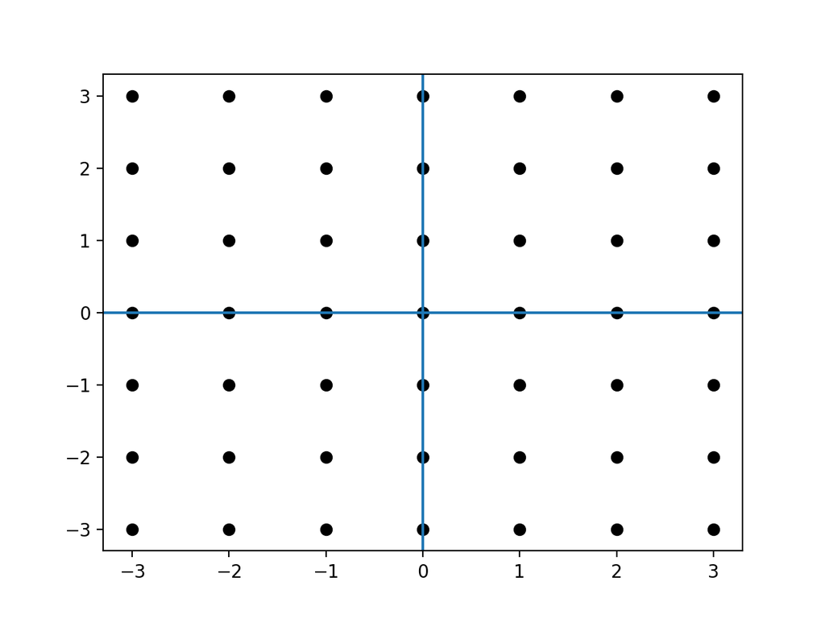

```python
x = np.arange(-3,4)
x, y = np.meshgrid(x, x)
v = np.arange(-2,3)

plt.figure("Empty Grid")
plt.plot(x, y, 'o', color = 'black')
plt.axhline()
plt.axvline()
```

### Connections to Spring

Can you label points that represent possible behavior for the different positions of the spring shown below?

[figure not shown]

$$\omega^2x^2 + v^2 = C$$

where $C \geq 0$ is some constant. This should line up with the familiar family of ellipses from high school mathematics.

**PROBLEM**

Now, suppose we have the harmonic oscillator from above expressed as

$$\dot{x} = v$$ $$\dot{v} = -\omega^2x$$

- Show that the orbits are given by ellipses $\omega^2x^2 + v^2 = C$ where $C$ is any non-negative constant. (Hint: Divide the $\dot{x}$ equation by the $\dot{v}$ equation, spearate the $v's$ from the $x's$, and integrate the resulting equation.
- Show that this condition is equivalent to conservation of energy!